## Notes about this template

1. This Jupyter Notebook is a template that must be used for A1, as it is aligned with the grading criteria. Not following this template may have an impact on the grade. Please follow all the instructions included here.
2. The appendix with the answers to the Data Ethics Decision Aid is to be handed in on a separate Canvas assignment, and in Word or PDF (not Jupyter notebook). See instructions on Canvas.

# Modelling Language for Predicting Podcast Engagement

- Student Name: Bruno NAdalic Sotic
- Student Number: 11353473
- Date: 26-03-2023
- Wordcount per section:
  - Introduction: 248
  - Hypotheses & Sub-RQs: 351
  - Gathering data: 302
  - Data Exploration & Evaluation: 448
  - Evaluation: 420
  - Limitations and Next Steps: 384
  - Ethical and Normative Considerations: 291

### Introduction

In recent years, podcasts and podcasting have become increasingly popular, and Spotify, along with other tech giants, is attempting to break into this space (Grandviewresearch.com, 2021). However, finding and recommending relevant podcasts to users is a challenge, mainly because of the sheer number of diverse formats and a lack of audience understanding (Morris & Patterson, 2015). Although some previous research has explored the motivations behind why audiences listen to podcasts, such as for informational value (McClung & Johnson, 2010) and the ability to multitask while listening (Tsagkias et al., 2008), little is known about how the use of language and its degree of complexity influences podcast engagement and general appeal.

Research in spoken and audio media has consistently shown the importance of language use for audience engagement (Reddy et al., 2021), but podcasting is a unique medium that involves multiple communication elements, including language, music, and sound effects. This research aims to fill the gap in knowledge by examining how the use of language and its degree of complexity influences podcast engagement. Specifically, it seeks to explore whether podcasts with simple or more profound use of language impact podcast engagement and to what extent.

Given that Spotifys main value proposition is its recommendation system that it has mastered through music, understanding how language use impacts podcast engagement is crucial to the companys success in its podcast offerings. This research is relevant as it seeks to provide insights into how Spotify can better recommend podcasts to users and understand the factors that correspond with engagement, ultimately improving the user experience and increasing user engagement with the platform. The results could also serve as guideline for podcast creators to make more appealing content.

### Hypothesis

Previous research has established the role of language and its influence on audience engagement in different forms of media such as books(Ashok et al., 2013), movies (Mahdiloo & Izadpanah, 2017), and television (MacKrill et al., 2021). For instance, studies have shown that simple language use in news articles leads to higher comprehension and recall among readers and foster more engagement on average (Arrese et al., 2006).

In the context of podcasting, if the language is too simple, it may not grab the listener's attention or provide sufficient stimulation to maintain engagement. In contrast, if the language is too complex, it may overwhelm the listener, resulting in difficulty comprehending and retaining the information presented. Hence, the direction of this potential relationship is unclear. The following hypothesis is proposed:

H1: The degree of language complexity used in a podcast episode has a significant impact on its engagement, after controlling for other predictors.

To investigate this relationship, podcast engagement will be defined as the number of views (Wu et al., 2018), although this metric does not fully capture other factors such as likes, comments, or shares, which can also impact a podcast's visibility and recommendation to users. Therefore, those metrics could be potential covariates. To assess language complexity, the Flesch-Kincaid Grade Level will be operationalized, which measures readability based on sentence length and word complexity (Reddy et al., 2021).

It is also essential to consider other factors that may impact podcast engagement. Research indicates that shorter podcast episodes often lead to increased engagement (Tsagkias et al., 2008). Hence, these variables will be controlled in the analysis to avoid any confounding effects with language complexity.

### Data Gathering

The data collection for this study aimed to gather information on podcast performance metrics, engagement indicators, and podcast qualities, specifically language complexity measured through audio transcripts. Due to limitations with available podcast APIs, data was collected from YouTube, which is a large podcast distribution platform that provides engagement data and transcripts through its public API. The data collection method involved querying the YouTube API for the term "podcast" using a reliable tool developed by DMI UvA and filtering the results for English-speaking podcast episodes released between January 2022 and January 2023. This is a way to control for time, since older podcasts had more time to gather more engagement. A total of 412 podcast episodes were collected, with 26 variables. However, the variables of interest for this study are comment count, like count, view count, channel ID, category, and video ID. Thereofre, all other variables that are not mentioned can be removed from the dataset. Raw audio transcripts were obtained using the YouTube_transcript_api and indexed using each video's unique video ID. The variable names and definitions are seen in the table below:

| Variable Name | Definition |
| --- | --- |
| VideoID | The unique identifier for a sigle YT video. |
| ChannelID | Unique identifier for the publisher of the video. |
| Published at | Date and time the video was published on the platform. |
| Video Category Label | Classification tag assigned to a video based on its content. |
| DurationSec | The lenght of the video as measured in seconds. |
| ViewCount | The number of views (plays) the video has recieved. |
| LikeCount | Number of user likes on the video. |
| CommentCount | The number of user comments a video has recieved. |
| Transcript | The raw audio transcript retrieved from the respective video. |

Privacy implications were considered during the data collection process, and the dataset will be anonymized with respect to the podcast episode's publisher. However, privacy risks could arise if the transcripts contain sensitive and/or personal information. The only way to mitigate this is to encrypt the dataset, which was beyond the scope of this research.

Furthermore, selection bias could have been introduced as the data collection involved querying for a specific term, potentially excluding certain podcasts. Additionally, the data collection procedure might have been subject to algorithmic bias, introduced by the YouTube algorithm's promotion of certain podcasts or creators over others, potentially affecting the accuracy of engagement metrics and the representation of different types of podcasts and creators in the dataset. These limitations will be considered when interpreting the findings and generalizing the results.

The two datasets are imported and loaded with the following code chunk. Afterwards, the datasets are merged based on their primary key.

```python
import pandas as pd
```

```python
youtube_podcast_df = pd.read_csv('youtube_podcasts.csv')
podcasts_transcripts_df = pd.read_csv('podcast_youtube_transcripts.csv')
```

**Merging datasets**

Before merging the two datasets, it is essential to ensure that the assumptions are met for the primary key. The primary key, in this case, is the videoId column, which needs to be present in both datasets, it must be unique and have no missing values. This is done using the following code:

```python
# quality check on the video id column
#check dataset lenght
print("Length of df1:", len(youtube_podcast_df))
print("Length of df2:", len(podcasts_transcripts_df))
# check missing values
print("Missing values in df1:\n", youtube_podcast_df['videoId'].isnull().sum())
print("Missing values in df2:\n", podcasts_transcripts_df['videoId'].isnull().sum())
# check duplicates
print("Duplicate values in df1:\n", youtube_podcast_df['videoId'].duplicated().sum())
print("Duplicate values in df2:\n", podcasts_transcripts_df['videoId'].duplicated().sum())
```

```
Length of df1: 412
Length of df2: 412
Missing values in df1:
 0
Missing values in df2:
 0
Duplicate values in df1:
 0
Duplicate values in df2:
 0
```

The next step is to merge the two dataset using the 'VideoID' column as primary key.

```python
podcasts = pd.merge(youtube_podcast_df, podcasts_transcripts_df, on='videoId')
len(podcasts)
```

```
412
```

```python
podcasts.head()
```

|  | position | channelId | channelTitle | videoId | publishedAt | publishedAtSQL | videoTitle | videoDescription | tags | videoCategoryId | ... | defaultLanguage | defaultLAudioLanguage | thumbnail_maxres | licensedContent | viewCount | likeCount | dislikeCount | favoriteCount | commentCount | Transcript |
| --- | --- | --- | --- | --- | --- | --- | --- | --- | --- | --- | --- | --- | --- | --- | --- | --- | --- | --- | --- | --- | --- |
| 0 | 1 | UC9yRXKq58_XkpeOcKjwqyjA | Angie Martinez | Y5pBkYb0jSw | 2022-12-26T18:55:06Z | 2022-12-26 18:55:06 | Kim Kardashian \| Angie Martinez IRL Podcast | This week on Angie Martinez IRL Podcast, Angie... | NaN | 22 | ... | NaN | NaN | https://i.ytimg.com/vi/Y5pBkYb0jSw/maxresdefau... | 1.0 | 1561837 | 36205.0 | NaN | 0 | 6398.0 | Andrew Martinez in Real Life podcast this epis... |
| 1 | 2 | UC5AQEUAwCh1sGDvkQtkDWUQ | Theo Von | jreBmGkuEBc | 2022-08-09T07:00:14Z | 2022-08-09 07:00:14 | Joe Rogan \| This Past Weekend w/ Theo Von #403 | Joe Rogan hosts Theo at his studio in Austin f... | Theo Von,This Past Weekend,TPW,comedy,podcast,... | 23 | ... | NaN | en-US | https://i.ytimg.com/vi/jreBmGkuEBc/maxresdefau... | 1.0 | 10651401 | 137837.0 | NaN | 0 | 11452.0 | i want to announce some upcoming tour dates i'... |
| 2 | 3 | UCbk_QsfaFZG6PdQeCvaYXJQ | Jay Shetty Podcast | ZjIRYn7x8sk | 2022-09-12T11:15:01Z | 2022-09-12 11:15:01 | Kendall Jenner Opens Up About Anxiety, Insecur... | Today, I sit down with the one and only Kendal... | Jay Shetty,Jay Shetty Podcast,Jay Shetty Inter... | 27 | ... | NaN | en-US | https://i.ytimg.com/vi/ZjIRYn7x8sk/maxresdefau... | 1.0 | 2342099 | 70353.0 | NaN | 0 | 2263.0 | if your happiness depends on the actions of ot... |
| 3 | 4 | UCGeBogGDZ9W3dsGx-mWQGJA | IMPAULSIVE | i39nHfUh2rQ | 2022-10-04T21:22:10Z | 2022-10-04 21:22:10 | Shaq Talks Kobe Regrets, Why LeBron Isn’t GOAT... | 4x NBA champion turned business mogul, Shaquil... | podcast guest,Jake Paul brother,impaulsive,imp... | 24 | ... | en | en | https://i.ytimg.com/vi/i39nHfUh2rQ/maxresdefau... | 1.0 | 3427150 | 103117.0 | NaN | 0 | 3942.0 | every zoo that I went to in the world all the ... |
| 4 | 5 | UCGX7nGXpz-CmO_Arg-cgJ7A | PBD Podcast | iv-C4CVGk28 | 2022-09-13T17:00:11Z | 2022-09-13 17:00:11 | Exclusive: Andrew Tate UNCENSORED Interview wi... | Patrick Bet-David sits down with Andrew Tate i... | Patrick Bet-David,Valeutainment,The BetDavid P... | 24 | ... | NaN | en | NaN | 1.0 | 12381505 | 401214.0 | NaN | 0 | 51575.0 | when you have the youth the masculine youth of... |

5 rows × 26 columns

The lenght of the dataset matches the prvious two dataset which means we cna continue.

## Cleaning Data

After merging the dataset obtained from scraping metrics about the podcast episodes toghether with the transcript episodes, the dataset looks the following:

```python
podcasts.head()
```

|  | position | channelId | channelTitle | videoId | publishedAt | publishedAtSQL | videoTitle | videoDescription | tags | videoCategoryId | ... | defaultLanguage | defaultLAudioLanguage | thumbnail_maxres | licensedContent | viewCount | likeCount | dislikeCount | favoriteCount | commentCount | Transcript |
| --- | --- | --- | --- | --- | --- | --- | --- | --- | --- | --- | --- | --- | --- | --- | --- | --- | --- | --- | --- | --- | --- |
| 0 | 1 | UC9yRXKq58_XkpeOcKjwqyjA | Angie Martinez | Y5pBkYb0jSw | 2022-12-26T18:55:06Z | 2022-12-26 18:55:06 | Kim Kardashian \| Angie Martinez IRL Podcast | This week on Angie Martinez IRL Podcast, Angie... | NaN | 22 | ... | NaN | NaN | https://i.ytimg.com/vi/Y5pBkYb0jSw/maxresdefau... | 1.0 | 1561837 | 36205.0 | NaN | 0 | 6398.0 | Andrew Martinez in Real Life podcast this epis... |
| 1 | 2 | UC5AQEUAwCh1sGDvkQtkDWUQ | Theo Von | jreBmGkuEBc | 2022-08-09T07:00:14Z | 2022-08-09 07:00:14 | Joe Rogan \| This Past Weekend w/ Theo Von #403 | Joe Rogan hosts Theo at his studio in Austin f... | Theo Von,This Past Weekend,TPW,comedy,podcast,... | 23 | ... | NaN | en-US | https://i.ytimg.com/vi/jreBmGkuEBc/maxresdefau... | 1.0 | 10651401 | 137837.0 | NaN | 0 | 11452.0 | i want to announce some upcoming tour dates i'... |
| 2 | 3 | UCbk_QsfaFZG6PdQeCvaYXJQ | Jay Shetty Podcast | ZjIRYn7x8sk | 2022-09-12T11:15:01Z | 2022-09-12 11:15:01 | Kendall Jenner Opens Up About Anxiety, Insecur... | Today, I sit down with the one and only Kendal... | Jay Shetty,Jay Shetty Podcast,Jay Shetty Inter... | 27 | ... | NaN | en-US | https://i.ytimg.com/vi/ZjIRYn7x8sk/maxresdefau... | 1.0 | 2342099 | 70353.0 | NaN | 0 | 2263.0 | if your happiness depends on the actions of ot... |
| 3 | 4 | UCGeBogGDZ9W3dsGx-mWQGJA | IMPAULSIVE | i39nHfUh2rQ | 2022-10-04T21:22:10Z | 2022-10-04 21:22:10 | Shaq Talks Kobe Regrets, Why LeBron Isn’t GOAT... | 4x NBA champion turned business mogul, Shaquil... | podcast guest,Jake Paul brother,impaulsive,imp... | 24 | ... | en | en | https://i.ytimg.com/vi/i39nHfUh2rQ/maxresdefau... | 1.0 | 3427150 | 103117.0 | NaN | 0 | 3942.0 | every zoo that I went to in the world all the ... |
| 4 | 5 | UCGX7nGXpz-CmO_Arg-cgJ7A | PBD Podcast | iv-C4CVGk28 | 2022-09-13T17:00:11Z | 2022-09-13 17:00:11 | Exclusive: Andrew Tate UNCENSORED Interview wi... | Patrick Bet-David sits down with Andrew Tate i... | Patrick Bet-David,Valeutainment,The BetDavid P... | 24 | ... | NaN | en | NaN | 1.0 | 12381505 | 401214.0 | NaN | 0 | 51575.0 | when you have the youth the masculine youth of... |

5 rows × 26 columns

YTDT scrapes all possible information by deafult which collects a lot of unneccessary metadata in the process. Therefore, all variables except the variables of interest are dropped from the dataset:

```python
podcasts = podcasts.loc[:, ['videoId', 'channelId', 'publishedAt', 'videoCategoryLabel', 'durationSec', 'viewCount', 'likeCount', 'commentCount', 'Transcript']] # Still need to keep the ID since thts the primary key for merging
podcasts.head()
```

|  | videoId | channelId | publishedAt | videoCategoryLabel | durationSec | viewCount | likeCount | commentCount | Transcript |
| --- | --- | --- | --- | --- | --- | --- | --- | --- | --- |
| 0 | Y5pBkYb0jSw | UC9yRXKq58_XkpeOcKjwqyjA | 2022-12-26T18:55:06Z | People & Blogs | 3490 | 1561837 | 36205.0 | 6398.0 | Andrew Martinez in Real Life podcast this epis... |
| 1 | jreBmGkuEBc | UC5AQEUAwCh1sGDvkQtkDWUQ | 2022-08-09T07:00:14Z | Comedy | 2573 | 10651401 | 137837.0 | 11452.0 | i want to announce some upcoming tour dates i'... |
| 2 | ZjIRYn7x8sk | UCbk_QsfaFZG6PdQeCvaYXJQ | 2022-09-12T11:15:01Z | Education | 3239 | 2342099 | 70353.0 | 2263.0 | if your happiness depends on the actions of ot... |
| 3 | i39nHfUh2rQ | UCGeBogGDZ9W3dsGx-mWQGJA | 2022-10-04T21:22:10Z | Entertainment | 1553 | 3427150 | 103117.0 | 3942.0 | every zoo that I went to in the world all the ... |
| 4 | iv-C4CVGk28 | UCGX7nGXpz-CmO_Arg-cgJ7A | 2022-09-13T17:00:11Z | Entertainment | 3131 | 12381505 | 401214.0 | 51575.0 | when you have the youth the masculine youth of... |

Because of privacy concerns (as discussed in the previous chapter) the dataset will be pseudonymized by replacing the videoId and channelId with unique, random values respectively. For this, a simple function is written that loops over each item in the respective columns and assigns every unique value a pseudo ID.

```python
import numpy as np
def pseudonymize_dataset(df):
    #create a dictionary to map original videoId and channelId to new pseudo IDs
    videoId_dict = {}
    channelId_dict = {}
    videoId_count = 1
    channelId_count = 1001

    for i in range(len(df)):
        # assign a new pseudo ID to videoId
        if df.loc[i, 'videoId'] not in videoId_dict:
            videoId_dict[df.loc[i, 'videoId']] = np.random.randint(1, 1000)
        # assign the same pseudo ID to videoId if already assigned
        df.loc[i, 'videoId'] = videoId_dict[df.loc[i, 'videoId']]

        # assign a new pseudo ID to channelId
        if df.loc[i, 'channelId'] not in channelId_dict:
            channelId_dict[df.loc[i, 'channelId']] = np.random.randint(1001, 2000)
        # assign the same pseudo ID to channelId if already assigned
        df.loc[i, 'channelId'] = channelId_dict[df.loc[i, 'channelId']]

    return df
```

```python
anon_podcasts = pseudonymize_dataset(podcasts)
```

```python
anon_podcasts.head()
```

|  | videoId | channelId | publishedAt | videoCategoryLabel | durationSec | viewCount | likeCount | commentCount | Transcript |
| --- | --- | --- | --- | --- | --- | --- | --- | --- | --- |
| 0 | 665 | 1112 | 2022-12-26T18:55:06Z | People & Blogs | 3490 | 1561837 | 36205.0 | 6398.0 | Andrew Martinez in Real Life podcast this epis... |
| 1 | 492 | 1988 | 2022-08-09T07:00:14Z | Comedy | 2573 | 10651401 | 137837.0 | 11452.0 | i want to announce some upcoming tour dates i'... |
| 2 | 147 | 1927 | 2022-09-12T11:15:01Z | Education | 3239 | 2342099 | 70353.0 | 2263.0 | if your happiness depends on the actions of ot... |
| 3 | 429 | 1646 | 2022-10-04T21:22:10Z | Entertainment | 1553 | 3427150 | 103117.0 | 3942.0 | every zoo that I went to in the world all the ... |
| 4 | 75 | 1747 | 2022-09-13T17:00:11Z | Entertainment | 3131 | 12381505 | 401214.0 | 51575.0 | when you have the youth the masculine youth of... |

#### Data Quality

The following steps is to check the dataset for missing cases, incorrect information, data corruption, type validation and their distribution (data was already checked for duplicates in the previous chapter).

*Missing Values*

```python
print('The summary of the missing values in the anon_podcasts DataFrame is as follows:')

anon_podcasts.isna().sum()
```

```
The summary of the missing values in the anon_podcasts DataFrame is as follows:
```

```
videoId                0
channelId              0
publishedAt            0
videoCategoryLabel     0
durationSec            0
viewCount              0
likeCount              4
commentCount           3
Transcript            83
dtype: int64
```

```python
# drop missing values
anon_podcasts = anon_podcasts.dropna(subset=['Transcript'])
anon_podcasts = anon_podcasts.dropna(subset=['likeCount'])
anon_podcasts = anon_podcasts.dropna(subset=['commentCount'])
```

Validation:

```python
anon_podcasts.isna().sum()
```

```
videoId               0
channelId             0
publishedAt           0
videoCategoryLabel    0
durationSec           0
viewCount             0
likeCount             0
commentCount          0
Transcript            0
dtype: int64
```

There are no more missing values. The following step involves checking what type the data is and converting the types if neccessary so that the dataset is analysis-ready.

*Data Types*

The type of the variables in inspected with the following:

```python
anon_podcasts.head()
print(anon_podcasts.dtypes)
```

```
videoId                object
channelId              object
publishedAt            object
videoCategoryLabel     object
durationSec             int64
viewCount               int64
likeCount             float64
commentCount          float64
Transcript             object
dtype: object
```

On the other hand, the variables View Count and Duration in Seconds are stored as integers, while Like Count and Comment Count are stored as floats. However, since Like Count and Comment Count represent whole numbers, they need to be converted from float to integer data type. This is because a like or a comment can only be a whole number.

This is performed with the code below:

```python
anon_podcasts['likeCount'] = anon_podcasts['likeCount'].astype(int)
anon_podcasts['commentCount'] = anon_podcasts['commentCount'].astype(int)
```

```python
print(anon_podcasts.dtypes)
```

```
videoId               object
channelId             object
publishedAt           object
videoCategoryLabel    object
durationSec            int64
viewCount              int64
likeCount              int32
commentCount           int32
Transcript            object
dtype: object
```

All variable are now in the appropriate type. The next section involves the creation of the main independant variable, language complexity.

#### Calculating Language Complexity

This section involves the creation of the main independat variable - language complexity - and is based on the transcript of the spoken content form the podcast episodes. A popular readability test called the Flesch-Kincaid Grade Level Score evaluates a text's complexity by looking at its sentence structure, word choice, and other linguistic elements. The grade level required to understand the material is calculated using the average number of words per sentence and the average number of syllables per word. This score has been proven to be a trustworthy indicator of text complexity in the fields of education and linguistic study (Reddy et al., 2021). According to Xu et al. (2015), it has been applied to the analysis of a wide range of texts, including news items, academic publications, and social media posts.

For example, a sentence such as “This is a sample text that you want to evaluate for complexity.” has a low Flesch-Kincaid Grade Level Score, indicating that it can be easily understood by people with lower levels of education. On the other hand, a sentence such as “The intricate machinery of the human brain is still largely unknown to science” has a higher score, indicating that it requires a higher level of education to fully comprehend. This is demonstrated in the code below:

```python
import textstat

text = "This is a sample text that you want to evaluate for complexity."
flesch_score = textstat.flesch_kincaid_grade(text)

print(flesch_score)
```

```
6.8
```

Now the the equation is applied ot the dataset of interest. But before that, the transcript column needs to be cleaned using standrd NLP methods. this includes removing punctuations, convertin to lowercase, and making sure that the column is actualy read as string. Other steps, such as tokenization and lemitization, are not applied here as that would directly influence the flesch score. The score needs to be run on natural language as sentences, but avoiding characters that are not letters.

```python
import re

# define the preprocessing function
def preprocess_text(text):
    # remove punctuations and special characters
    text = re.sub(r'[^\w\s]', '', text)
    # onvert to lowercase
    text = text.lower()
    #remove digits
    text = re.sub(r'\d+', '', text)
    #remove extra whitespace
    text = re.sub(r'\s+', ' ', text)
    return text

#apply preprocessing to Transcript column
anon_podcasts['Transcript'] = anon_podcasts['Transcript'].apply(preprocess_text)
```

```python
anon_podcasts['Transcript'].head()
```

```
0    andrew martinez in real life podcast this epis...
1    i want to announce some upcoming tour dates il...
2    if your happiness depends on the actions of ot...
3    every zoo that i went to in the world all the ...
4    when you have the youth the masculine youth of...
Name: Transcript, dtype: object
```

The text is not in the appropriate format. The Flesch-Kincaid Grade Level Score is applied ot the Transcript column of the data frame and a new variable is made called 'fk_grade_level' and used to represent language complexity.

```python
#compute lnaguage complexity
anon_podcasts['fk_grade_level'] = anon_podcasts['Transcript'].apply(textstat.flesch_kincaid_grade)

print(anon_podcasts[['Transcript', 'fk_grade_level']].head())
```

```
                                          Transcript  fk_grade_level
0  andrew martinez in real life podcast this epis...          3985.5
1  i want to announce some upcoming tour dates il...          7636.3
2  if your happiness depends on the actions of ot...          4485.5
3  every zoo that i went to in the world all the ...          6615.3
4  when you have the youth the masculine youth of...         25826.7
```

Fk_grade_level is a numeric variable that quantifies the complexity of language used in each podcast episode. Although Fk_grade_level can be treated as a categorical variable, this approach may result in loss of precision, especially given the small size of the dataset. Therefore, following Reddy et als. (2021) advice, it will be kept as a numeric variable to maintain the accuracy of the analysis. Additionally, while it is possible to convert Fk_grade_level to whole numbers, it will be kept as decimal values to maintain more precision.

*ICR*

To assess the validity of this method, inter-coder reliability will be conducted. The first step is to export a random sample of 50 podcast transcripts and save it as a new csv (given that the transcripts are long, it was timely impossible to read through and code more than this).

```python
# assuming anon_podcasts is a pandas DataFrame
icr = pd.DataFrame(anon_podcasts, columns=['Transcript'])

# create a new DataFrame with 50 random rows from the original DataFrame
new_icr = icr.sample(n=50)

new_icr.to_csv("data_icr.csv", index=False)
```

[output not shown]

As mentioned, the language complexity score is a numerical decimal value and will not be operationalized into categories for the analysis in order to preserve accuracy. Since it is impossible to assign a similar numerical value to each podcast transcript, the categorization will be binary. '1' will be used to label podcasts that are deemed high in language complexity based on their vocabulary and structure, where '0' is used for the ones that are low in complexity. For the sake of the ICR, the automatic labeling will also be treated as a categorical classification. This might not provide full validity o this method, but toher options are beyond the scope of this study.

```python
icr_df = pd.read_csv("data_icr.csv", delimiter=';')
icr_df.head()
```

|  | Transcript | human label |
| --- | --- | --- |
| 0 | were all worried about your head but what abou... | 0 |
| 1 | whats up guys hey whats up hey whats up g i kn... | 0 |
| 2 | the fol0ing is a conversation with michael mal... | 1 |
| 3 | how do i know andrew tay is not part of the il... | 1 |
| 4 | hey there before we start the episode i want t... | 1 |

The next step is to again asign a language complexity score to each transcript and then categorise the data into either high or low language complexity absed on the median of the score.

```python
icr_df['complexity score'] = anon_podcasts['Transcript'].apply(textstat.flesch_kincaid_grade)

icr_df.head()
```

|  | Transcript | human label | complexity score |
| --- | --- | --- | --- |
| 0 | were all worried about your head but what abou... | 0 | 3985.5 |
| 1 | whats up guys hey whats up hey whats up g i kn... | 0 | 7636.3 |
| 2 | the fol0ing is a conversation with michael mal... | 1 | 4485.5 |
| 3 | how do i know andrew tay is not part of the il... | 1 | 6615.3 |
| 4 | hey there before we start the episode i want t... | 1 | 25826.7 |

```python
# Calculate the median value of fk_grade_level
fk_median = icr_df['complexity score'].median()

# Categorize the transcripts as high or low complexity based on the median
icr_df['complexity'] = [1 if x >= fk_median else 0 for x in icr_df['complexity score']]

# Display the resulting dataframe
icr_df.head()
```

|  | Transcript | human label | complexity score | complexity |
| --- | --- | --- | --- | --- |
| 0 | were all worried about your head but what abou... | 0 | 3985.5 | 0 |
| 1 | whats up guys hey whats up hey whats up g i kn... | 0 | 7636.3 | 1 |
| 2 | the fol0ing is a conversation with michael mal... | 1 | 4485.5 | 0 |
| 3 | how do i know andrew tay is not part of the il... | 1 | 6615.3 | 1 |
| 4 | hey there before we start the episode i want t... | 1 | 25826.7 | 1 |

Finally, the following steps calculates inter-coder reliability between the human label and automatic complexity score:

```python
from sklearn.metrics import cohen_kappa_score

# Extract the 'human label' and 'complexity' columns from icr_df
labels = icr_df['human label']
complexity = icr_df['complexity']

# Calculate Cohen's kappa coefficient
kappa = cohen_kappa_score(labels, complexity)
print("Cohen's kappa coefficient:", kappa)
```

```
Cohen's kappa coefficient: 0.6825396825396826
```

*Distributions & Outliers*

The following code prints the distribution of each variable relevant to the analysis. This is to inspects the distributions for outliers and irregularities:

```python
#descriptive statistics for each variable
anon_podcasts.describe()
```

|  | durationSec | viewCount | likeCount | commentCount | fk_grade_level |
| --- | --- | --- | --- | --- | --- |
| count | 324.000000 | 3.240000e+02 | 3.240000e+02 | 324.000000 | 324.000000 |
| mean | 1604.317901 | 1.511520e+06 | 4.369940e+04 | 3285.077160 | 6025.965123 |
| std | 1213.729358 | 2.708336e+06 | 1.062157e+05 | 5841.406302 | 4760.102922 |
| min | 4.000000 | 1.000000e+00 | 0.000000e+00 | 0.000000 | 20.400000 |
| 25% | 422.250000 | 1.958565e+05 | 5.136250e+03 | 333.750000 | 2006.700000 |
| 50% | 1420.500000 | 6.748350e+05 | 1.606200e+04 | 1438.500000 | 5480.800000 |
| 75% | 2807.250000 | 1.702080e+06 | 3.875700e+04 | 3970.250000 | 8828.675000 |
| max | 3591.000000 | 3.025014e+07 | 1.074224e+06 | 60888.000000 | 25826.700000 |

*note: descriptive statistics will be discussed in EDA*

The dataset appears to have a skewed distribution, with the mean being higher than the median for all variables. The variable with the most extreme outliers is the dependent variable (viewCount), with some values being significantly higher than the rest. Specifically, there are observations with viewCount values greater than 5 million, while most observations have viewCount values under 2 million.

To address this, extreme outliers will be removed from the viewCount variable, defined as values above the upper limit of 75th percentile. This choice is made to balance the need for retaining as much data as possible while also avioding undue influence on the analytical model from a few extreme observations.

Additionally, it is noted that the variable durationSec has a minimum value of 4, which is unlikely to represent a relevant podcast episode. Therefore, all observations with durationSec values under 100 seconds are removed to ensure that the dataset only contains meaningful observations.

```python
podcasts_clean = anon_podcasts[anon_podcasts['durationSec'] >= 100]
```

```python
len(podcasts_clean)
```

```
289
```

```python
import numpy as np
#upper limit for outliers based on the 75th percentile and IQR
Q1 = np.percentile(podcasts_clean['viewCount'], 25)
Q3 = np.percentile(podcasts_clean['viewCount'], 75)
IQR = Q3 - Q1
upper_limit = Q3 + 1.5 * IQR

# remove observations above upper limit DV
podcasts_clean = podcasts_clean[podcasts_clean['viewCount'] <= upper_limit]
len(podcasts_clean)
```

```
267
```

The dataset is not considered clean and is ready for an exploritory analysis.

## Data Exploration & Evaluation

```python
podcasts_clean.head()
```

|  | videoId | channelId | publishedAt | videoCategoryLabel | durationSec | viewCount | likeCount | commentCount | Transcript | fk_grade_level |
| --- | --- | --- | --- | --- | --- | --- | --- | --- | --- | --- |
| 0 | 665 | 1112 | 2022-12-26T18:55:06Z | People & Blogs | 3490 | 1561837 | 36205 | 6398 | andrew martinez in real life podcast this epis... | 3985.5 |
| 2 | 147 | 1927 | 2022-09-12T11:15:01Z | Education | 3239 | 2342099 | 70353 | 2263 | if your happiness depends on the actions of ot... | 4485.5 |
| 3 | 429 | 1646 | 2022-10-04T21:22:10Z | Entertainment | 1553 | 3427150 | 103117 | 3942 | every zoo that i went to in the world all the ... | 6615.3 |
| 5 | 946 | 1597 | 2022-10-07T16:36:10Z | Science & Technology | 1999 | 796367 | 18250 | 1941 | i have anal beads that are communicating with ... | 14925.8 |
| 6 | 354 | 1597 | 2022-10-17T16:45:49Z | Science & Technology | 2922 | 1197139 | 23446 | 2078 | you and magnus played a private game games of ... | 13860.4 |

```python
len(podcasts_clean)
```

```
267
```

#### DV: View Count

```
count    2.670000e+02
mean     8.594280e+05
std      9.216634e+05
min      1.000000e+00
25%      1.715020e+05
50%      5.299190e+05
75%      1.224843e+06
max      3.486925e+06
Name: viewCount, dtype: float64
```

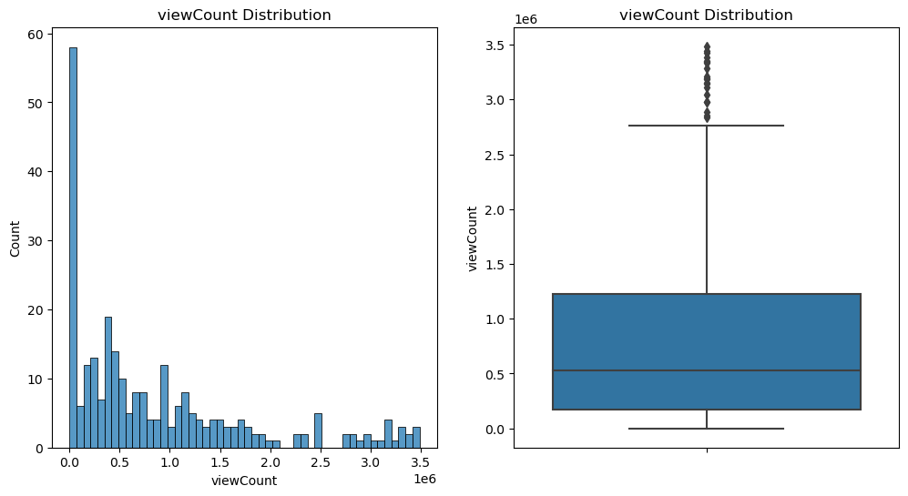

```python
#summary
print(podcasts_clean['viewCount'].describe())

import matplotlib.pyplot as plt
import seaborn as sns
# visualize distribution with histogram and boxplot side by side
fig, axs = plt.subplots(1, 2, figsize=(12, 6))
sns.histplot(podcasts_clean['viewCount'], bins=50, ax=axs[0])
sns.boxplot(y=podcasts_clean['viewCount'], ax=axs[1])
axs[0].set_title('viewCount Distribution')
axs[1].set_title('viewCount Distribution')
plt.show()
```

#### IV: Language Complexity

```
count      267.000000
mean      6196.174157
std       4361.746088
min        105.800000
25%       3002.350000
50%       5859.900000
75%       8689.350000
max      24684.400000
Name: fk_grade_level, dtype: float64
```

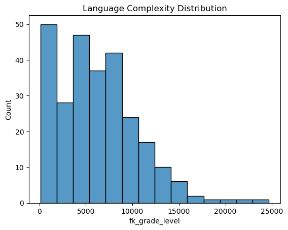

```python
print(podcasts_clean['fk_grade_level'].describe())

plt.subplot()
sns.histplot(podcasts_clean['fk_grade_level'])
plt.title('Language Complexity Distribution')
```

#### Engagment Metrics as Control: Comment Count and Like Count

```
           likeCount  commentCount
count     267.000000    267.000000
mean    20558.059925   2270.494382
std     23020.341124   2838.965200
min         0.000000      0.000000
25%      3621.000000    272.000000
50%     13214.000000   1347.000000
75%     29948.500000   3131.000000
max    113550.000000  18950.000000
```

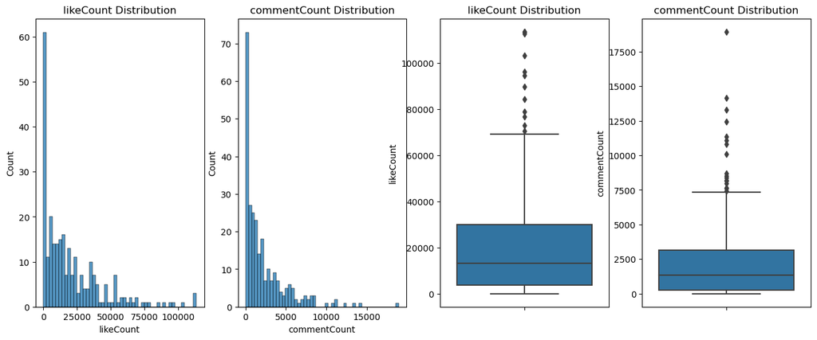

```python
#descriptives
print(podcasts_clean[['likeCount', 'commentCount']].describe())

import matplotlib.pyplot as plt
import seaborn as sns

#visuals
fig, axs = plt.subplots(1, 4, figsize=(16, 6))

sns.histplot(podcasts_clean['likeCount'], bins=50, ax=axs[0])
sns.histplot(podcasts_clean['commentCount'], bins=50, ax=axs[1])
sns.boxplot(y=podcasts_clean['likeCount'], ax=axs[2])
sns.boxplot(y=podcasts_clean['commentCount'], ax=axs[3])

axs[0].set_title('likeCount Distribution')
axs[1].set_title('commentCount Distribution')
axs[2].set_title('likeCount Distribution')
axs[3].set_title('commentCount Distribution')

plt.show()
```

likeCount and commentCount, have a wide variation with mean values of 20,558 and 2,270, respectively, and significant skewness to the right. There are also some potential biases in the data as some podcasts have zero likes or comments.

#### Channels & Video Categories

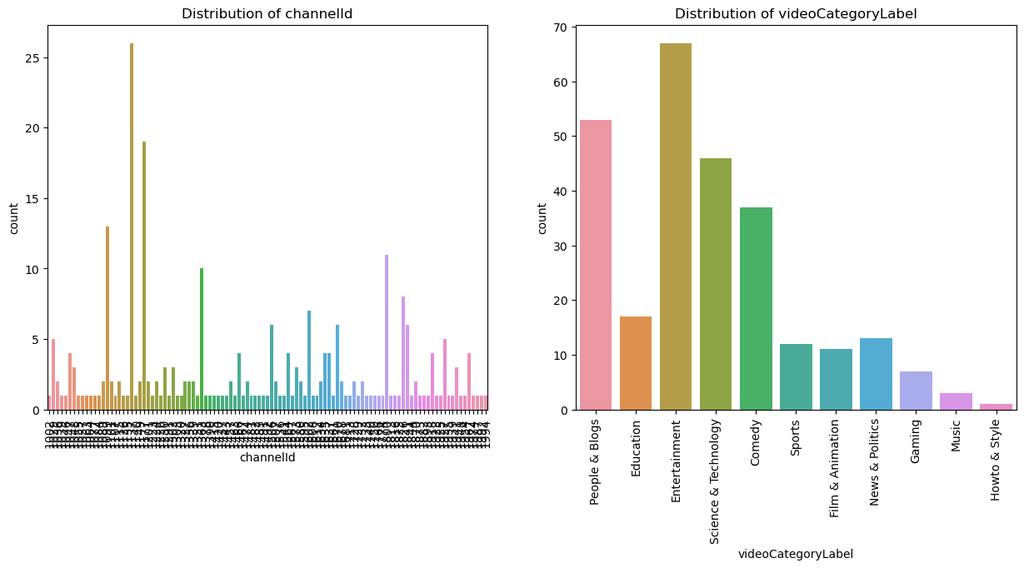

```python
# create a figure with 1 row and 2 columns
fig, ax = plt.subplots(1, 2, figsize=(15, 6))

#plot distribution of unique values
sns.countplot(x='channelId', data=podcasts_clean, ax=ax[0])
ax[0].set_xticklabels(ax[0].get_xticklabels(), rotation=90)
ax[0].set_title('Distribution of channelId')

#plot distribution of unique values in videoCategoryLabel variable
sns.countplot(x='videoCategoryLabel', data=podcasts_clean, ax=ax[1])
ax[1].set_xticklabels(ax[1].get_xticklabels(), rotation=90)
ax[1].set_title('Distribution of videoCategoryLabel')

plt.show()
```

Podcasts in the dataset come from various channels, but a few of them are more dominant than others. In terms of genre, the podcasts span across a diverse range of categories, with "Entertainment" being the most common and "How to" being the least common.

#### Duration in Seconds

```
count     267.000000
mean     1778.940075
std      1153.434921
min       108.000000
25%       692.000000
50%      1717.000000
75%      2887.500000
max      3591.000000
Name: durationSec, dtype: float64
```

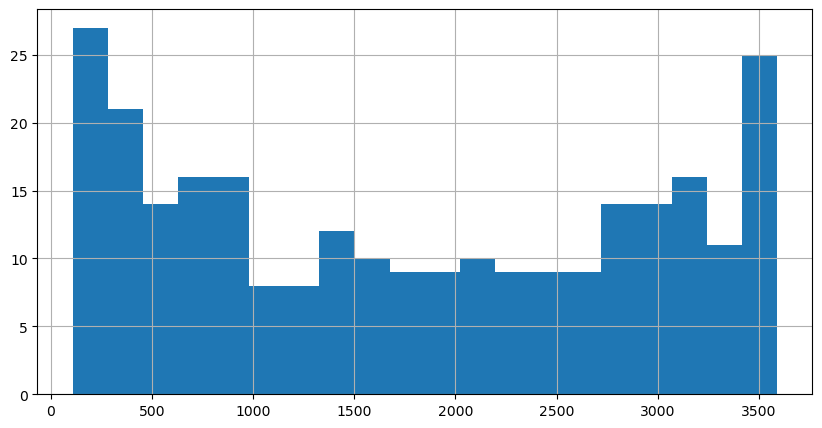

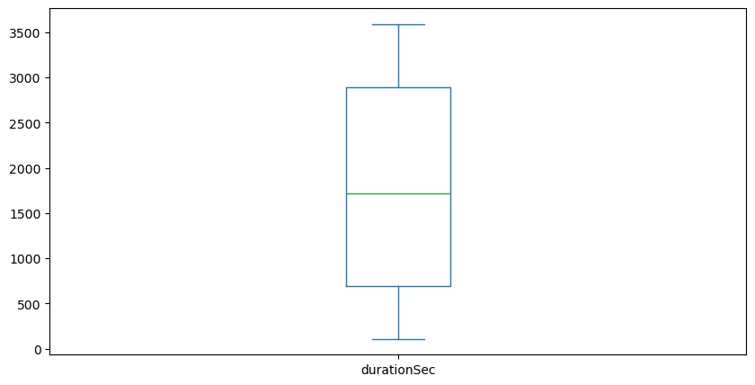

```python
# descriptives
print(podcasts_clean['durationSec'].describe())

# plot histogram
podcasts_clean['durationSec'].hist(bins=20, figsize=(10,5))
plt.show()

# box plot
podcasts_clean['durationSec'].plot(kind='box', figsize=(10,5))
plt.show()
```

The duration variable ranges from 108 to 3591 seconds, with a mean of 1778.94 seconds and a standard deviation of 1153.43 seconds. The distribution is roughly symmetric, indicating that the length of podcasts varies widely from very short to much longer.

#### Correlation Matrix

```
                viewCount  likeCount  commentCount  durationSec  \
viewCount        1.000000   0.874349      0.702266     0.105338
likeCount        0.874349   1.000000      0.695999     0.049974
commentCount     0.702266   0.695999      1.000000     0.079914
durationSec      0.105338   0.049974      0.079914     1.000000
fk_grade_level   0.373765   0.232031      0.348060     0.149957

                fk_grade_level
viewCount             0.373765
likeCount             0.232031
commentCount          0.348060
durationSec           0.149957
fk_grade_level        1.000000
```

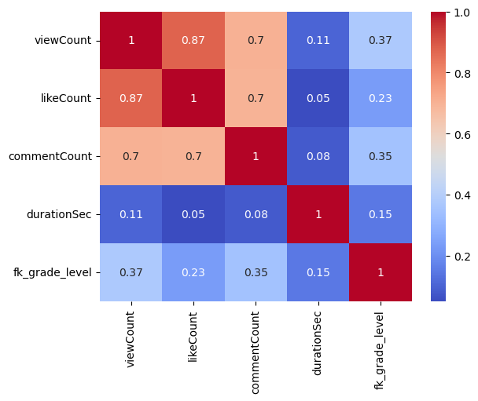

```python
#select columns
numerical_cols = ['viewCount', 'likeCount', 'commentCount', 'durationSec', 'fk_grade_level']

#create a correlation matrix
corr_matrix = podcasts_clean[numerical_cols].corr()

# create a heat map of the correlation matrix
sns.heatmap(corr_matrix, cmap='coolwarm', annot=True)

print(corr_matrix)
```

The correlation matrix indicates that viewCount and likeCount are highly positively correlated (0.874), and viewCount and commentCount are moderately correlated (0.702). The correlation between fk_grade_level and other variables is weak, with the highest correlation being 0.373 with viewCount. DurationSec shows weak correlation with all variables, with the highest correlation of 0.15 with fk_grade_level. The findings suggest that viewCount and likeCount are important factors affecting engagement in the podcasts, while the relationship between fk_grade_level and engagement is weaker. Multicollinearity between viewCount and commentCount is also possible.

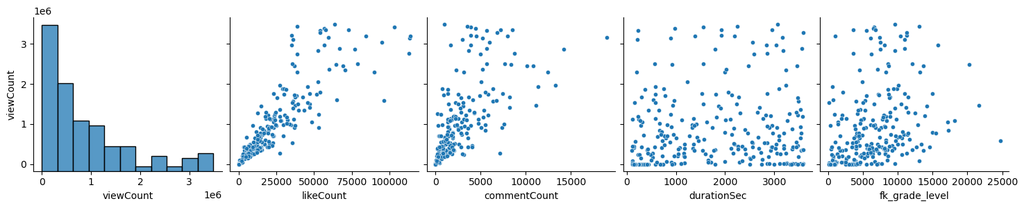

```python
#create a pair plot with scatter plots for each variable against viewCount
sns.pairplot(podcasts_clean[numerical_cols], y_vars=['viewCount'], height=3, plot_kws=dict(s=20))
plt.show()
```

Scatter plots were created to examine the relationship between the independent variables and the dependent variable. 'likeCount' and 'commentCount' appear to have a linear relationship with the target variable, while duration does not show any linear relationship, and the relationship for fk_grade_level is unclear.

#### Conclusion

ViewCount (DV) and likeCount were found to have a strong positive correlation, with viewCount and commentCount also showing a moderately strong positive correlation. In contrast, fk_grade_level had weak correlations with all other variables, this is also true for duration.

The scatter plots showed that likeCount and commentCount had a linear relationship with the target variable (viewCount), while duration showed no signs of linearity. It was difficult to determine the linearity of fk_grade_level. It is difficult to assess the strenght and direction of the relationship between language complexity and view count, which will be explored further in a hypothesis test.

## Modeling and Hypothesis Testing

The objective of this research is to examine the influence of language complexity, represented by the Flesch-Kincaid (FK) grade level, on podcast episode engagement, indicated by the view count, while accounting for other predictors. During the exploratory data analysis (EDA), it was found that most variables exhibit a right-skewed distribution with numerous outliers. To mitigate this issue, a more robust models will be used and evaluated to test the hypothesis. As there are correlations between the dependent variable (view count) and predictor variables, it may be beneficial to include both in the model. However, since view count and like count are also correlated, addressing multicollinearity is necessary (a problem when trying to interpret the effect of each independent variable).

During the EDA, it was also observed that certain variables had stronger correlations than others, while the relationships between language complexity and view count might not strictly be linear. Scatterplots between the independent and dependent variables displayed scattered patterns without clear linear trends. The relationship might be more complex. This also needs to be accounted for when choosing the model.

Given the potential violation of the normality assumption, caution is advised when interpreting results from hypothesis testing. The final model selection will involve comparing the performance of different models using R-squared and mean squared error.

Considering these factors, two distinct models will be employed to test the hypothesis: robust regression and a random forest regressor. Robust regression is a linear model designed to account for outliers in data. Since outliers were identified earlier, the robust regression method is an appropriate approach to address them. The method is also useful for handling skewed data (Larose, 2014).

A random forest model will also be utilized, as it is well-suited for data with multiple independent variables potentially impacting the dependent variable. Furthermore, correlations were observed between some independent variables, and a random forest model can effectively manage multicollinearity among predictors. Furthermore, a random forest model is a good option for potential non-linear relationships between the DV and IV (Larose, 2014).

The models are trained and then evaluated using the code below:

```python
import pandas as pd
import numpy as np
from sklearn.model_selection import train_test_split
from sklearn.linear_model import LinearRegression
from sklearn.ensemble import RandomForestRegressor
from sklearn.metrics import r2_score, mean_squared_error
from sklearn.svm import SVR
import statsmodels.api as sm
import statsmodels.formula.api as smf

# Define the IV and DV
X = podcasts_clean[['likeCount', 'commentCount', 'durationSec', 'fk_grade_level']]
y = podcasts_clean['viewCount']

#split the data into training and testing sets
X_train, X_test, y_train, y_test = train_test_split(X, y, test_size=0.2, random_state=42)

#fit a Robust regression model
robust_model = sm.RLM(y_train, sm.add_constant(X_train), M=sm.robust.norms.HuberT()).fit()
robust_y_pred = robust_model.predict(sm.add_constant(X_test))
robust_r_squared = r2_score(y_test, robust_y_pred)
robust_rmse = np.sqrt(mean_squared_error(y_test, robust_y_pred))

# fit a Random Forest model
rf_model = RandomForestRegressor(n_estimators=100, random_state=42)
rf_model.fit(X_train, y_train)
rf_y_pred = rf_model.predict(X_test)
rf_r_squared = r2_score(y_test, rf_y_pred)
rf_rmse = np.sqrt(mean_squared_error(y_test, rf_y_pred))

# print the results
print('Robust R-squared: ', robust_r_squared)
print('Robust RMSE: ', robust_rmse)
print('Random Forest R-squared: ', rf_r_squared)
print('Random Forest RMSE: ', rf_rmse)
```

```
Robust R-squared:  0.826965028425792
Robust RMSE:  408772.23258357175
Random Forest R-squared:  0.8145653932287434
Random Forest RMSE:  423165.0953778007
```

The robust R-squared value of 0.827 indicates that the robust regression model explains about 83% of the variance in the dependent variable using the independent variables. The robust RMSE value of 408,772 indicates that on average, the model's predictions are off by around 408,772 views.

The Random Forest R-squared value of 0.815 indicates that the Random Forest model explains about 81% of the variance in the dependent variable using the independent variables. The Random Forest RMSE value of 423,165 indicates that on average, the model's predictions are off by around 423,165 views.

Both models perform relatively well in explaining the variance in the dependent variable, and their RMSE values are quite similar. However, the robust regression performs slightly better. Therefore, this model will be used to test the hypothesis. This is doen with the following:

```python
print(robust_model.summary())
```

```
                    Robust linear Model Regression Results
==============================================================================
Dep. Variable:              viewCount   No. Observations:                  213
Model:                            RLM   Df Residuals:                      208
Method:                          IRLS   Df Model:                            4
Norm:                          HuberT
Scale Est.:                       mad
Cov Type:                          H1
Date:                Thu, 04 May 2023
Time:                        12:14:55
No. Iterations:                     2
==================================================================================
                     coef    std err          z      P>|z|      [0.025      0.975]
----------------------------------------------------------------------------------
const          -4.129e+04   3.45e+04     -1.196      0.232   -1.09e+05    2.64e+04
likeCount         28.9255      0.969     29.845      0.000      27.026      30.825
commentCount      49.2102      8.498      5.791      0.000      32.554      65.866
durationSec       12.0855     12.845      0.941      0.347     -13.090      37.261
fk_grade_level    19.7569      3.688      5.358      0.000      12.529      26.985
==================================================================================

If the model instance has been used for another fit with different fit parameters, then the fit options might not be the correct ones anymore .
```

In the robust linear model regression results, the coefficient for the constant term is -4.129e+04 (SE = 3.45e+04), z = -1.196, p = .232. This indicates that the constant is not statistically significant at the .05 level, suggesting that the intercept term may not be necessary in the model. However, in some cases this indicates that the model might not accurately capture the relationship between the DV and the IVs.

The coefficients for the predictor variables likeCount, commentCount, and fk_grade_level are all statistically significant with p-values less than .05. The coefficient for durationSec variable, however, is not statistically significant at the .05 level (p = .347).

The model can be additionally evaluted through a scatter plot that compares the actual values of a variable with the predicted values:

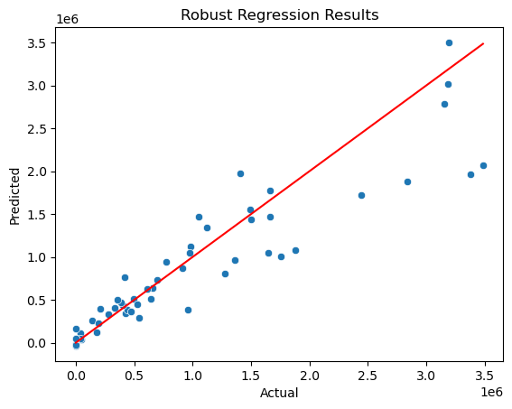

```python
import seaborn as sns
import matplotlib.pyplot as plt

# create a dataframe with the actual and predicted values
df = pd.DataFrame({'Actual': y_test, 'Predicted': robust_y_pred})

# create a scatter plot
sns.scatterplot(x='Actual', y='Predicted', data=df)

# add a line representing perfect predictions
x_plot = np.linspace(0, max(y_test), 100)
plt.plot(x_plot, x_plot, color='red')

# add labels and title
plt.xlabel('Actual')
plt.ylabel('Predicted')
plt.title('Robust Regression Results')

# show the plot
plt.show()
```

In predictive modeling, we use various features (like likes, comments, duration, and fk grade level) to predict the IV ( view count). However, not all features contribute equally to the predictive power of the model. Therefore, it is essential to determine the relative importance of each feature. This is done through permutation - a technique used to assess the importance of input features by randomly permuting (i.e., shuffling) the values of a single feature and measuring the resulting impact on a model (Larose, 2014).

```python
from sklearn.linear_model import RANSACRegressor

# fit the model
model = RANSACRegressor(random_state=0).fit(X_train, y_train) #for some reason, the robust regression needs to be specified in this way for permutation

# calculate feature importance
results = permutation_importance(model, X_test, y_test)

# get importance
importance = results.importances_mean

# summarize
for i,v in enumerate(importance):
    print('Feature: %0d, Score: %.5f' % (i,v))
```

```
Feature: 0, Score: 1.03238
Feature: 1, Score: 0.05898
Feature: 2, Score: 0.00911
Feature: 3, Score: 0.01604
```

The results show that the most important feature is Feature 0, which corresponds to 'likeCount' in the original dataset, with a score of 1.03238. This indicates that the number of likes is the most important predictor of the number of views. Feature 1, which corresponds to 'commentCount', has a relatively low score of 0.05898, suggesting it has a minor effect on the number of views. Features 2 and 3 have even lower scores, indicating that they are likely not important predictors of the number of views in this model.

## Evaluation

The analysis aimed to explore the factors that affect engagement (measure through views) of podcasts on YouTube, mainly testing the hypothesis that language complexity plays a significant role in predicting podcast engagement.

The results of the robust regression and Random Forest models showed that the models perform relatively well in explaining the variance in the dependent variable, and their RMSE values are quite similar, with the robust regression performing slightly better. The results suggest that the number of likes, comments, and fk grade level (language complexity index) are statistically significant factors that impact the number of views, while the duration of the video is not a significant predictor.

This might have implications for Spotify’s recommendation system and content curation. By taking into account the language complexity of podcasts, Spotify can improve the accuracy of its recommendations and better tailor content to individual users. Content creators can use this information to optimize their podcast titles and descriptions for maximum visibility and reach. Furthermore, this information can be used to identify popular language styles and themes among users, leading to the development of new and more relevant content.

Although, the the model used might not have been the most optimal fit for the data, this was a pilot study that showed promising results for future research. It is recomended that Spotifys R&D team use this information to steer their research into a similar direction and test the hypothesis again on a larger set of observations. This could then inspire a development approach for more tailored recommendations. Additionally, the results suggest that Spotify could provide content creators with guidelines on optimizing their podcasts for language complexity to increase visibility and reach. Finally, Spotify could conduct further research to better understand the relationship between language complexity and user engagement, including whether this relationship varies across different user groups or content genres.

### Limitations and Next Steps

This study explored the relationship between language complexity and podcast engagement using data collected from a single platform, YouTube. This creates a limitation in terms of generalizability, as results may not hold true for other podcast platforms. Additionally, the data collection method relied on web scraping by using the YouTube API querying a single term, which may have resulted in biases introduced through retrieval, as well as the recommendation algorithm. Additionally, a fundamental limitation is the size of the dataset as it amounted to ~250 observations after the data was cleaned.

View count was used as the sole engagement metric, which may be naive as it can be easily manipulated and might not be an accurate representation of engagement. Other engagement metrics such as likes, comments, or shares could have been taken into account as dependent variables as well. They were included as covariates, but there may be other external factors influencing engagement or view count that were not controled for. This research also did not account for other spoken and non-spoken qualities or the brand of the podcast that could affect engagement.

Language complexity was operationalized using the Flesch-Kincaid Grade Level Score. There are multiple measures of language complexity that may produce different results. The way in which language complexity was operationalized might be outdated, and more novel machine learning models would be better for this. The dataset had outliers and was heavily skewed, and required better diagnostics to validate assumptions, check for multicollinearity, and homoscedasticity. The regression results in the present research showed an insignificant constant, which might mean that the results are invalid.

Future research could collect data from multiple podcast platforms to validate the results and try to replicate the findings using more variables. Additionally, alternative measures of language complexity could be. Natural Language Processing (NLP) methods could also be used to obtain a more sophisticated measure of language complexity. A promising model could be BERT. It is also suggested to find a better proxy for user engagement, one that utilizes views, likes, comments and shares simultaneously. Understanding audience engagement could also be complemented with qualitative data in a follow-up study.

Future research should also consider using different modeling techniques that can handle complex data structures, to provide a more sophisticated understanding of phenomena and perform the necessary diagnostic checks.

## Ethical and Normative Considerations

One of the main ethical considerations is the protection of user privacy. While the podcast data and metadata used in this study was publicly available, there is a risk that individuals' personal information may be inadvertently disclosed (Beligi & Liu, 2018). It is important to ensure that any data used for research purposes is anonymized and aggregated to prevent identification of individual users.

Furthermore, collecting data by querying for a specific term can introduce bias into the dataset. In this case, the dataset may overrepresent certain types of podcasts or creators, such as those with more views or subscribers. Additionally, the dataset may exclude podcasts that do not use the term 'podcast' in their titles, descriptions, or tags. This bias can affect the generalizability of the findings and limit the scope of the analysis (Arioldi et at., 2016).

### References

Airoldi, Massimo, Davide Beraldo, and Alessandro Gandini. “Follow the Algorithm: An Exploratory Investigation of Music on YouTube.” Poetics 57 (August 1, 2016): 1–13. https://doi.org/10.1016/j.poetic.2016.05.001.

Aldous, Kholoud Khalil, Jisun An, and Bernard J. Jansen. “What Really Matters?: Characterising and Predicting User Engagement of News Postings Using Multiple Platforms, Sentiments and Topics.” Behaviour & Information Technology 0, no. 0 (February 7, 2022): 1–24. https://doi.org/10.1080/0144929X.2022.2030798.

Beigi, Ghazaleh, and Huan Liu. “Privacy in Social Media: Identification, Mitigation and Applications.” arXiv, August 6, 2018. https://doi.org/10.48550/arXiv.1808.02191.

Chen, Xi, and Shuo Shi. “A Literature Review of Privacy Research on Social Network Sites.” In 2009 International Conference on Multimedia Information Networking and Security, 1:93–97, 2009. https://doi.org/10.1109/MINES.2009.268.

Deng, Qi, Yun Wang, Michel Rod, and Shaobo Ji. “Speak to Head and Heart: The Effects of Linguistic Features on B2B Brand Engagement on Social Media.” Industrial Marketing Management 99 (November 1, 2021): 1–15. https://doi.org/10.1016/j.indmarman.2021.09.005.

Entman, Robert M. “How the Media Affect What People Think: An Information Processing Approach.” The Journal of Politics 51, no. 2 (May 1989): 347–70. https://doi.org/10.2307/2131346.

Ganjigunte Ashok, Vikas, Song Feng, and Yejin Choi. “Success with Style: Using Writing Style to Predict the Success of Novels.” In Proceedings of the 2013 Conference on Empirical Methods in Natural Language Processing, 1753–64. Seattle, Washington, USA: Association for Computational Linguistics, 2013. https://aclanthology.org/D13-1181.

MacKrill, Kate, Connor Silvester, James W. Pennebaker, and Keith J. Petrie. “What Makes an Idea Worth Spreading? Language Markers of Popularity in TED Talks by Academics and Other Speakers.” Journal of the Association for Information Science and Technology 72, no. 8 (2021): 1028–38. https://doi.org/10.1002/asi.24471.

Mahdiloo, Abolfaz, and Siros Izadpanah. “The Impact of Humorous Movie Clips on Better Learning of English Language Vocabulary.” International Journal of Research in English Education 2, no. 2 (June 10, 2017): 16–29. https://doi.org/10.18869/acadpub.ijree.2.2.16.

Marín Arrese, Juana Isabel, and Begoña Núñez Perucha. “Evaluation and Engagement in Journalistic Commentary and News Reportage,” November 2006. https://doi.org/10.14198/raei.2006.19.13.

McClung, Steven, and Kristine Johnson. “Examining the Motives of Podcast Users.” Journal of Radio & Audio Media 17, no. 1 (May 6, 2010): 82–95. https://doi.org/10.1080/19376521003719391.

Morris, Jeremy Wade, and Eleanor Patterson. “Podcasting and Its Apps: Software, Sound, and the Interfaces of Digital Audio.” Journal of Radio & Audio Media 22, no. 2 (July 3, 2015): 220–30. https://doi.org/10.1080/19376529.2015.1083374.

“Podcasting Market Size, Share, Trends & Growth Report, 2030.” Accessed May 4, 2023. https://www.grandviewresearch.com/industry-analysis/podcast-market. Reddy, Sravana, Mariya Lazarova, Yongze Yu, and Rosie Jones. “Modeling Language Usage and Listener Engagement in Podcasts.” In Proceedings of the 59th Annual Meeting of the Association for Computational Linguistics and the 11th International Joint Conference on Natural Language Processing (Volume 1: Long Papers), 632–43. Online: Association for Computational Linguistics, 2021. https://doi.org/10.18653/v1/2021.acl-long.52.

Tsagkias, M., M. Larson, W. Weerkamp, and M. de Rijke. PodCred: A Framework for Analyzing Podcast Preference. New York, NYAssociation for Computing Machinery (ACM), 2008. https://dare.uva.nl/search?identifier=0282f405-fc38-4e47-b8be-e550f68dd8c6.

Wiley.com. “Discovering Knowledge in Data: An Introduction to Data Mining, 2nd Edition | Wiley.” Accessed May 4, 2023. https://www.wiley.com/en-us/Discovering+Knowledge+in+Data%3A+An+Introduction+to+Data+Mining%2C+2nd+Edition-p-9780470908747.

Wu, Siqi, Marian-Andrei Rizoiu, and Lexing Xie. “Beyond Views: Measuring and Predicting Engagement in Online Videos.” Proceedings of the International AAAI Conference on Web and Social Media 12, no. 1 (June 15, 2018). https://doi.org/10.1609/icwsm.v12i1.15031.